# Markdown and the Normal Distribution

Brian Gerber

7/7/2026

# R Markdown

RStudio can help you use Markdown to create HTML/PDF/Word documents that can embed R code, HTML, CSS, latex (type setting language), and more. This is a good [website](https://www.markdownguide.org/) to checkout for markdown coding.

Markdown is quite useful for developing reports or doing homeework. Anytime you want to combile code, plotting, or analyses with text, markdown can help. We will use markdown as a way accomplish homework. This way you can provide code and document it simultaneously. I would suggest to not try and get too fancy at first. Keep it simple. Write-text in RStudio as you would in any word processor. Write R code in R chunks. Use “echo=FALSE” and “echo=TRUE” for a code chunk to either not print the code or to print the code.

### The Normal Distribution

This probability function is the most widely used and heard of. It has amazing utility. Let’s get to know it a bit more intimately.

Let’s create an R chunk and plot some data by simulating from a random variable `y`. Let’s define this variable such that it can take on values of any real number from $-\infty$ to $\infty$. So, $y \in (-\infty, \infty)$ or $y \in \mathbb{R}$.

More specifically, let’s define `y` as having a probability density function of a Normal/Gaussian distribution,

$$y \sim \text{Normal}(\mu,
\sigma).$$

And stated more generally as,

$$f(y;\mu, \sigma) = [y|\mu,
\theta].$$

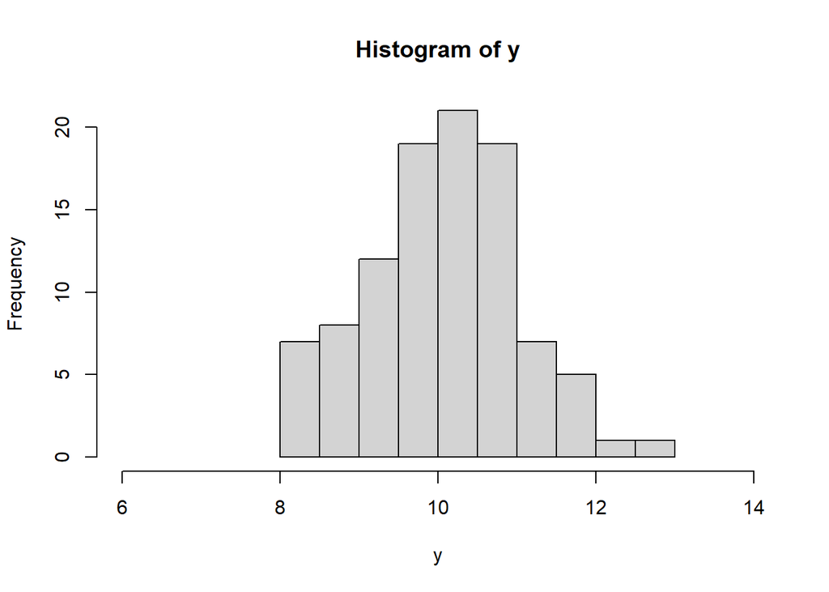

```r
# Simulate data from a standard normal distribution (mu = 10, sd = 1)
  set.seed(54235)
  y = rnorm(n = 100,
            mean = 10,
            sd = 1
            )

# Create a histogram
  hist(y,xlim=c(6,14))
```

Let’s create a new plot and not output the code. This time we will see the true probability distribution, not simulated values.

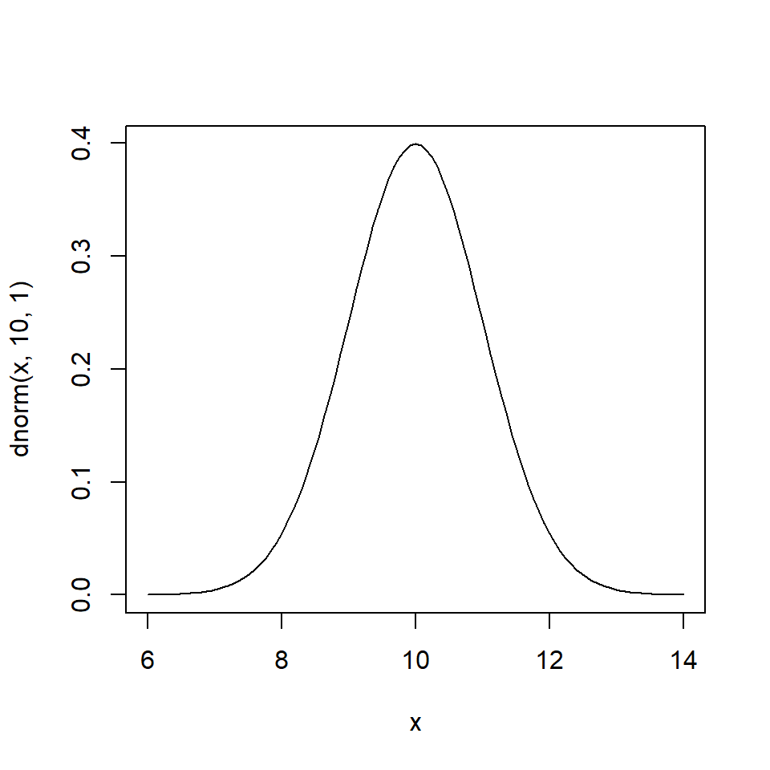

HTML code can be embedded, such as turning text a different color.

Simple text formatting can be done directly, such as *italics* or **bolding**.

# Equations

Markdown uses latex to embed very nice equations. For example, the expectation of random variable `y` is the integral from limits a to b of `y` multiplied by the probability density of `y`:

$$E[y] = \int_a^b y \times f(y; \mu,
\sigma) dy$$
More so, you can use a lot of functionality of latex and make the expectation more clear as,
$$\begin{align*}
E[y] =& \int_{-\infty}^{\infty} y\times
\frac{1}{\sigma\sqrt(2\pi)}e^{-1/2(\frac{y-\mu}{\sigma})^2} dy \\
E[y] =& \mu.
\end{align*}$$

But what is the *expected value*? Summarizing [wikipedia](https://en.wikipedia.org/wiki/Expected_value), the expected value (also called expectation, expectancy, expectation operator, mathematical expectation, mean, expectation value, or first moment of a probability function) is a generalization of the weighted average.

Informally, the expected value is the arithmetic mean of the possible values a random variable can take, weighted by the probability of those outcomes. For symmetric distributions, like the Normal, the expected value is in the middle of the distribution, thus it is also the mode probable (i.e. mode). This is not the case for non-symmetric distributions (i.e., left side of the distribution has a long tail and the right side does not have the same long tail).

## Approximating an Integral

Let’s understand the expected value math a bit more. What we are doing is for every value of `y` possible ($-\infty$ to $\infty$), we multiple it by its probability density. Then we take all these values and add them (i.e., the integral).

It’s a bit easier to understand what the math is doing by making an approximation, which breaks it into pieces.

We can approximate the integral by breaking it into pieces to calculate `y` times the $f(y; \mu, \sigma)$ and then sum all these values.

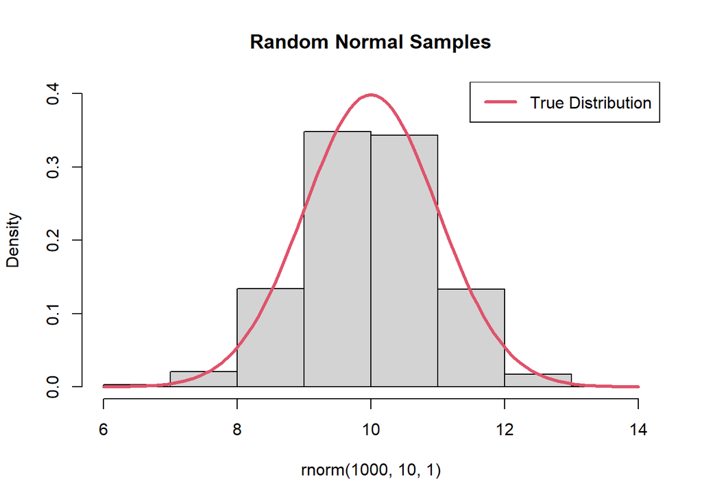

```r
# Create a histogram and save the values
  set.seed(14341)
  y.hist=hist(rnorm(1000,10,1),breaks=8, freq=FALSE,ylim=c(0,0.4),
              main="Random Normal Samples")

# Plot the true probabiltiy denisty.
  curve(dnorm(x,10,1),add=TRUE,lwd=3,col=2)
  legend("topright",lwd=3,col=c(2),legend="True Distribution")
```

```r
# Get the x-axis mid-points of each bin
  mid.point.x=y.hist$mids
  mid.point.x
```

```
## [1]  6.5  7.5  8.5  9.5 10.5 11.5 12.5 13.5
```

```r
# Get the y-axis values (probability density) for each value.
  prob.y=y.hist$density
  prob.y
```

```
## [1] 0.003 0.021 0.134 0.348 0.343 0.133 0.017 0.001
```

```r
# multiple these value and sum them to get the approximated expected value

  sum(prob.y*mid.point.x)
```

```
## [1] 9.979
```

Does this answer make sense?

What if you did the same approximation with more simulated values and bins? Perhaps our approximation would get closer to the true value ($\mu = 10$)?